# Exercise 2 of “Big Data Analytics” (Winter Semester 2020/21)

# Task 3: Entropy

To make our code more generic, we define variables for the dataset and the prediction target. This allows swapping the dataset if we wanted.

```r
dataset <- iris
target <- "Species"
```

## a) Split Entropy for Attribute

Here is the implementation of the split entropy function:

```r
splitEntropy <- function(x, y, splitPoint) {
  # Get indices of values left and right from splitPoint
  idx.s1 <- which(x <= splitPoint)
  idx.s2 <- which(x > splitPoint)
  # Get estimates for the probability of class labels
  prob.s1 <- table(y[idx.s1]) / length(idx.s1)
  prob.s2 <- table(y[idx.s2]) / length(idx.s2)
  # Compute both entropies (corner case: if prob = 0, then entropy = 0)
  entropy.s1 <- -sum(ifelse(prob.s1 > 0, prob.s1 * log2(prob.s1), 0))
  entropy.s2 <- -sum(ifelse(prob.s2 > 0, prob.s2 * log2(prob.s2), 0))
  # Return entropy of split
  if (length(idx.s1) == 0) { # splitPoint less than all values in x
    return(entropy.s2)
  }
  if (length(idx.s2) == 0) { # splitPoint greater than/equal to all values in x
    return(entropy.s1)
  }
  return((length(idx.s1)*entropy.s1 + length(idx.s2)*entropy.s2) / length(y))
}
```

Note that we do not need any loops, but rely on vectorized operations. We first find out to which part of the split each data object belongs. Second, we count the occurrence of class labels in each split with the `table()` function. Third, we compute the entropy in each split. Note that some class labels might not occur in a split, in which case we would have to compute the logarithm of 0. In entropy computation, we can set $0*log_2(0) := 0$. Forth, we weight the entropies of each split with the number of data objects in the split.

Let’s try our test cases. We should not directly compare for equality because we use floating-point operations. With floats, there always is the possibility of small numerical differences (not specific to R). Thus, we compute the differences between actual and expected values and check if they are reasonably small.

```r
x <- 1:5
y <- factor(c(1, 1, 1, 0, 0))
differences <- c(
  splitEntropy(x, y, 0) - -sum(c(3/5, 2/5)*log2(c(3/5, 2/5))),
  splitEntropy(x, y, 2.5) - -3/5*sum(c(1/3, 2/3)*log2(c(1/3, 2/3))),
  splitEntropy(x, y, 3.5) - 0
)
stopifnot(all(abs(differences) < 1e-10))
```

Looks good, the `stopifnot` assertion statement didn’t crash, which means we passed the test. By the way, you can also write proper unit tests with the `testthat` package:

```r
library(testthat)
test_that("Entropy computation works", {
  x <- 1:5
  y <- factor(c(1, 1, 1, 0, 0))

  expect_equal(splitEntropy(x, y, 0), -sum(c(3/5, 2/5)*log2(c(3/5, 2/5))))
  expect_equal(splitEntropy(x, y, 2.5), -3/5*sum(c(1/3, 2/3)*log2(c(1/3, 2/3))))
  expect_equal(splitEntropy(x, y, 3.5), 0)
})
```

This does not have many benefits in our small example, apart from some numerical tolerance when comparing floats. `testthat` is quite helpful when having a larger code base. E.g., when writing a package, you can simply run all tests of the package.

## b) Split Entropy for Dataset

Again, let’s have a look at the implementation right away:

```r
splitEntropyForData <- function(dataset, target) {
  # Initialize result
  result <- list()
  # For each attribute (i.e., all columns except the target) ...
  for (attribute in setdiff(colnames(dataset), target)) {
    # Get all possible split values
    splits <- sort(as.numeric(unique(dataset[, attribute])))
    # Compute entropy for each split
    entropies <- sapply(splits, FUN = splitEntropy, x = dataset[, attribute],
                        y = dataset[, target])
    # Store result
    curr.result <- cbind(splits, entropies) # create matrix
    colnames(curr.result) <- c("Split", "Entropy")
    result[[attribute]] <- curr.result
  }
  return(result)
}
```

We have two loops, one over attributes (`for`) and one over split points (`sapply`). Note that we don’t want to compute splits for the target variable itself, so we exclude it with the `setdiff()` function. As split points, we use all values occurring in an attribute. Another possibility would be to use all points in the middle between two attribute values. With `unique()`, we remove duplicate values. The task doesn’t define the structure of the result. We decided to create a list with one component for each attribute. Each component stores a matrix of split points and entropies. This will be useful once we start plotting.

## c) Plot

Given our function definition, computing all split entropies is very easy:

```r
dataSplitEntropy <- splitEntropyForData(dataset, target = target)
str(dataSplitEntropy)
```

```
List of 4
 $ Sepal.Length: num [1:35, 1:2] 4.3 4.4 4.5 4.6 4.7 4.8 4.9 5 5.1 5.2 ...
  ..- attr(*, "dimnames")=List of 2
  .. ..$ : NULL
  .. ..$ : chr [1:2] "Split" "Entropy"
 $ Sepal.Width : num [1:23, 1:2] 2 2.2 2.3 2.4 2.5 2.6 2.7 2.8 2.9 3 ...
  ..- attr(*, "dimnames")=List of 2
  .. ..$ : NULL
  .. ..$ : chr [1:2] "Split" "Entropy"
 $ Petal.Length: num [1:43, 1:2] 1 1.1 1.2 1.3 1.4 1.5 1.6 1.7 1.9 3 ...
  ..- attr(*, "dimnames")=List of 2
  .. ..$ : NULL
  .. ..$ : chr [1:2] "Split" "Entropy"
 $ Petal.Width : num [1:22, 1:2] 0.1 0.2 0.3 0.4 0.5 0.6 1 1.1 1.2 1.3 ...
  ..- attr(*, "dimnames")=List of 2
  .. ..$ : NULL
  .. ..$ : chr [1:2] "Split" "Entropy"
```

We can use default R plot functionality:

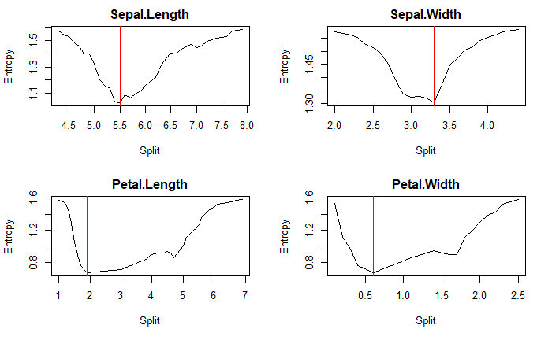

```r
par(mfrow = c(2,2)) # multiple plots in a grid
for (attribute in names(dataSplitEntropy)) {
  plotData <- data.frame(dataSplitEntropy[[attribute]])
  plot(x = plotData$Split, y = plotData$Entropy, main = attribute,
       xlab = "Split", ylab = "Entropy", type = "l")
  abline(v = plotData[which.min(plotData$Entropy), "Split"], col = "red")
}
par(mfrow = c(1,1))
```

As we have multiple attributes, we create a grid with sub-plots to show all results at the same time. We mark the split point resulting in the lowest entropy with a vertical red line. As we can see, the extreme values of each attribute are associated with high split entropy. This makes sense, as these split points would only separate a few data objects. Even if this small set was quite pure regarding the class distribution, the remaining larger set would still contain objects from all classes in roughly equal proportion. For each attribute, the minimum split entropy is considerably smaller than the maximum split entropy. However, even the minimum is far from the theoretical optimum of zero. As we have three classes, and one split can only separate one class from the two others, this is expected.

Alternatively, we could also use `ggplot2`:

[figure not shown]

```r
library(ggplot2)
plots <- lapply(names(dataSplitEntropy), function(attribute) {
  plotData <- data.frame(dataSplitEntropy[[attribute]])
  ggplot(data = plotData) +
    geom_line(mapping = aes(x = Split, y = Entropy)) +
    geom_vline(xintercept = plotData[which.min(plotData$Entropy), "Split"], color = "red") +
    labs(title = attribute)
})
gridExtra::grid.arrange(grobs = plots, nrow = 2, ncol = 2)
```

Here, we need the `gridExtra` package to combine plots into a grid.

## d) Split Finding

The best split is the split which results in the lowest entropy. The general idea is to compute the lowest entropy for each attribute first and then the global minimum over that. To show you some more R functionality, we don’t simply solve this with loops (or their vectorized alternatives) over our result list, but combine the results in one `data.frame`.

```r
splitTable <- data.frame(Attribute = names(dataSplitEntropy)[1], dataSplitEntropy[[1]])
for (attribute in names(dataSplitEntropy)[-1]) {
  splitTable <- rbind(splitTable, data.frame(Attribute = attribute,
                                             dataSplitEntropy[[attribute]]))
} # combine all split and entropy values in one table
str(splitTable)
```

```
'data.frame':   123 obs. of  3 variables:
 $ Attribute: chr  "Sepal.Length" "Sepal.Length" "Sepal.Length" "Sepal.Length" ...
 $ Split    : num  4.3 4.4 4.5 4.6 4.7 4.8 4.9 5 5.1 5.2 ...
 $ Entropy  : num  1.57 1.54 1.53 1.48 1.46 ...
```

Next, we can compute the minimum per attribute and the global minimum, together with its split attribute and split point.

```r
aggregate(Entropy ~ Attribute, splitTable, min)  # min entropy for each attribute
```

| Attribute | Entropy |
| --- | --- |
| Petal.Length | 0.6666667 |
| Petal.Width | 0.6666667 |
| Sepal.Length | 1.0277298 |
| Sepal.Width | 1.3018365 |

```r
bestSplitAttribute <- as.character(splitTable[which.min(splitTable$Entropy), "Attribute"])
bestSplitPoint <- splitTable[which.min(splitTable$Entropy), "Split"]
bestSplitAttribute
```

```
[1] "Petal.Length"
```

```r
bestSplitPoint
```

```
[1] 1.9
```

```r
splitEntropy(x = dataset[, bestSplitAttribute], y = dataset[[target]], splitPoint = bestSplitPoint)
```

```
[1] 0.6666667
```

`data.frame`s don’t have a nice group-by functionality, though we can use the `aggregate()` function. Looking back to exercise 1, task 3 b), the split point seems to be capable of separating the species `setosa` from the other two species. In fact, this can be achieved with both `Petal.Length` and `Petal.Width`. In contrast, classes are less separated for the other two attributes. Thus, their optimal split entropy is higher.

As an alternative to `data.frame`, we could also use `data.table`, which extends basic `data.frame`s, but also changes the syntax of some of the existing operations.

```r
library(data.table)
splitTable <- rbindlist(lapply(names(dataSplitEntropy), function(attribute) {
  return(cbind(Attribute = attribute, data.table(dataSplitEntropy[[attribute]])))
})) # combine all split and entropy values in one table
str(splitTable)
```

```
Classes ‘data.table’ and 'data.frame':  123 obs. of  3 variables:
 $ Attribute: chr  "Sepal.Length" "Sepal.Length" "Sepal.Length" "Sepal.Length" ...
 $ Split    : num  4.3 4.4 4.5 4.6 4.7 4.8 4.9 5 5.1 5.2 ...
 $ Entropy  : num  1.57 1.54 1.53 1.48 1.46 ...
 - attr(*, ".internal.selfref")=<externalptr>
```

As you just saw, we can easily combine a list of `data.table`s with `rbindlist`.

```r
splitTable[, .(Entropy = min(Entropy)), by = Attribute] # min entropy for each attribute
```

| Attribute | Entropy |
| --- | --- |
| Sepal.Length | 1.0277298 |
| Sepal.Width | 1.3018365 |
| Petal.Length | 0.6666667 |
| Petal.Width | 0.6666667 |

```r
splitTable[, .(Split = Split[Entropy == min(Entropy)]), by = Attribute] # split with min entropy for each attribute
```

| Attribute | Split |
| --- | --- |
| Sepal.Length | 5.5 |
| Sepal.Width | 3.3 |
| Petal.Length | 1.9 |
| Petal.Width | 0.6 |

```r
bestSplitAttribute <- splitTable[which.min(Entropy), Attribute]
bestSplitPoint <- splitTable[which.min(Entropy), Split]
bestSplitAttribute
```

```
[1] "Petal.Length"
```

```r
bestSplitPoint
```

```
[1] 1.9
```

```r
splitEntropy(x = dataset[, bestSplitAttribute], y = dataset[[target]], splitPoint = bestSplitPoint)
```

```
[1] 0.6666667
```

Here, we can get the min entropy per attribute without `aggregate()`. The `.(Entropy = ...)` construct basically means `SELECT ... AS Entropy`. We could also write `splitTable[, min(Entropy), by = Attribute]`, which would rename `Entropy` to `V1` after aggregation. We can even get the split where entropy is minimal for each attribute. This is quite powerful, though it looks strange in the beginning. Note we don’t need to quote column names. Furthermore, we only need to write the name `splitTable` once per statement, and the column names are automatically evaluated in the context of that `data.table`.